# Hough Transform

https://en.wikipedia.org/wiki/Hough_transform

Hough transform is primarily used to extract and describe shapes in a photo.  
Most often it is used to detect straight lines but it can be used to detect other shapes like circles, elypses, polygons or any other form that can be described with an equation.

## How it works

### Setup

Imagine you want to describe a straight line. The most common way it would be to use the *slope-intercept* form:

$$ y=mx+b $$

A straight line in this form could be represented as a point (m,b) in the parameter space. A problem arises if the line we are trying to describe is vertical. In that case the slope parameter $ m $ would be unbounded. For this reason the Hough transform uses a *normal* form:

$$ r=xcosθ + ysinθ $$

where $ r $ is the length of the normal line from the origin to the closest point on the straight line, and $ \theta $ is the angle between the x axis and the normal line.

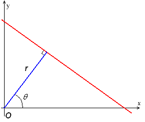

Using normal form we can represent a line as a point ($r$, $θ$) in the parameter space.

### Transform

#### Example 1: Computer vision

Since Hough transform is mainly used in computer vision applications let's start by a simple line detection example.

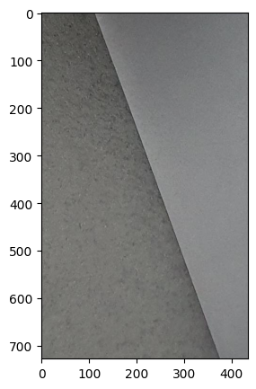

```python
import matplotlib.pyplot as plt
import matplotlib.image as mpimg
import cv2 as cv

plt.rcParams["figure.figsize"] = (10,5)

sample_photo_path = 'resources/laptop_small.jpeg'
img = mpimg.imread(sample_photo_path)
plt.imshow(cv.flip(img, 0),cmap = 'gray')
plt.show()
```

We'll use OpenCV's Canny Edge Detector to detect lines on this photo.  
More on Canny Edge Detector: https://en.wikipedia.org/wiki/Canny_edge_detector  
The image is first converted to greyscale and then the edges are extracted as shown below.

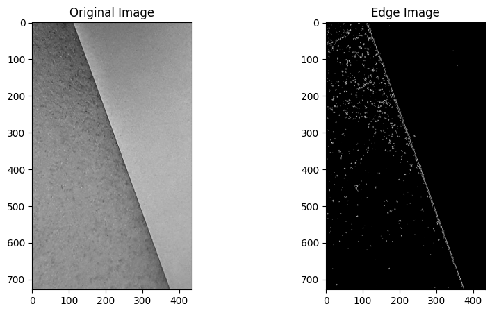

```python
img = cv.imread(sample_photo_path,0)

# need to flip the image vertically as the open cv package puts the origin in the top left corner
edges = cv.Canny(img,100,100)
plt.subplot(121),
plt.imshow(cv.flip(img, 0),cmap = 'gray')
plt.title('Original Image')
plt.subplot(122),
plt.imshow(cv.flip(edges, 0),cmap = 'gray')
plt.title('Edge Image')
plt.show()
```

As expected there appears to be 1 straight line in the photo.  
Some noise was detected, but that will not matter as Hough Transform will be able to ignore it.

Now we can perform Hough transform in order to retrieve lines from the "edge image" and describe them in normal and slope-intercept forms.

We need to iterate over all white pixes (points) as they are potentially a part of a line.  
In each point we need to calculate parameter $r$ "for each possible" line going through that point.  
Obiously there are infinite number of lines that can pass through any point so we need to determine the number of angles $θ$ we would like to check this for.  
This way we can calculate all possible parameter pairs ($r$,$θ$) for the specific point.

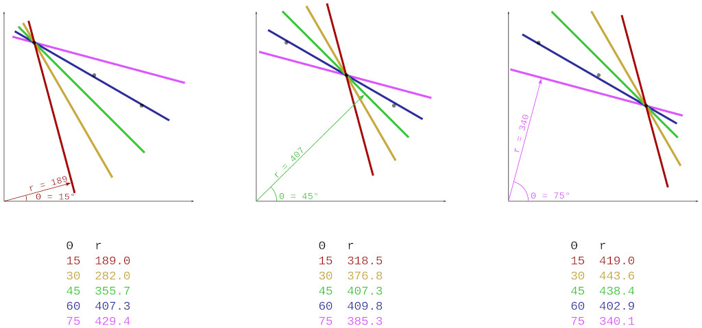

Source: https://en.wikipedia.org/wiki/Hough_transform#/media/File:Hough_transform_diagram.svg

Each pair of parameters is a point in Hough space (parameter space). In order to store all the points in parameter space we need to create a 2D matrix called the **accumulator**.  
The dimensions of the accumulator are the number of angles $\theta$ we want to use and the number of approximated values for parameter $r$ we want to use. A good initiall value for both numbers is 180. This means we increase $\theta$ for 1° each time and we have 180 possible approximations for $r$.  
The accumulator is initialized with zeroes and each time we evaluate the parameters we increase the appropriate cell in the matrix by one. This is called voting as each possible line adds 1 vote.  
The cells in the accumulator with high number of votes are our solutions as all lines with the same orientation $\theta$ and distance from the origin $r$ are collinear.

Here is a simple implementation with comments:

```python
import numpy as np
import pandas as pd

def basic_hough(data, num_r, num_theta):
    """
    A basic hough transform implementation
    """

    # calculate step size of thetas and create an array of theta values
    step_theta = 180 / num_theta # angle step size will be 0.5 degree
    theta_values = np.arange(0, 180, step=step_theta)

    # precalculate cosine and sine values of theta angles
    theta_values_cos = np.cos(np.deg2rad(theta_values))
    theta_values_sin = np.sin(np.deg2rad(theta_values))

    # maximum value for r is the max distance from the origin
    # let's use pythagorean theorem to calculate that from the height and width of the image

    height, width = data.shape
    distance_max = np.sqrt(height**2 + width**2)
    r_step = (2 * distance_max) / num_r
    r_values = np.arange(-distance_max, distance_max, step=r_step)

    # initialize accumulator matrix
    # accumulator = np.zeros((len(r_values), len(theta_values)))
    r_len = len(r_values)
    theta_len = len(theta_values)
    accumulator = np.zeros((r_len, theta_len))

    for y in range(0, len(data)-1):
        for x in range(0, len(data[y])-1):
            edge = data[y][x]
            # only consider pixels detected by Canny
            if edge > 0:
                for theta_idx in range(0,len(theta_values)-1): # evaluate for all possible theta angles
                    # calculate r for given theta
                    rho = (x * theta_values_cos[theta_idx]) + (y * theta_values_sin[theta_idx])
                    # find the closest r index in the accumulator
                    rho_idx = np.argmin(np.abs(r_values - rho))
                    # increase the value in the accumulator
                    accumulator[rho_idx][theta_idx] += 1

    return accumulator, theta_values, r_values
```

```python
accumulator, theta_values, r_values = basic_hough(edges, 360, 360)
```

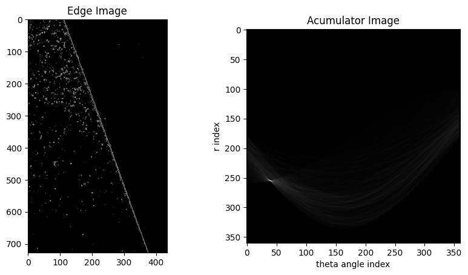

```python
# lets see how the accumulator looks like
plt.rcParams["figure.figsize"] = (10,5)

plt.subplot(121)
plt.imshow(cv.flip(edges, 0),cmap = 'gray')
plt.title('Edge Image')
plt.subplot(122)
plt.imshow(accumulator,cmap = 'gray')
plt.ylabel('r index')
plt.xlabel('theta angle index')
plt.title('Acumulator Image')
plt.show()
```

Each pixel in the edge image is transformed into a curve in the accumulator image (due to rotation over all possible angles). Here I chose resolution of 360 to make the final line fit the image better (we rotate a line on each step by 0.5 degrees)  
All pixels that lie on the long straight line in the edge image end up with the same $r$ value at the same $\theta$ angle forming a bright spot in the accumulator image.  
Let's check which accumulator cell got the most votes:

```python
max_rho_idx, max_theta_idx = np.unravel_index(accumulator.argmax(), accumulator.shape)

print(f'Accumulator cell with most votes: ({max_rho_idx}, {max_theta_idx})')
```

```
Accumulator cell with most votes: (255, 40)
```

Let's find corresponding $r$ and $\theta$ values for the cell.

```python
max_theta = theta_values[max_theta_idx]
max_r = r_values[max_rho_idx]

print(f'Theta: {max_theta}')
print(f'R: {max_r}')
```

```
Theta: 20.0
R: 353.1455869121835
```

This means that the normal line to the detected edge is at a 20° angle and has length of approx 353 units (pixels). </br></br>

Let's transform the line into the slop-intercept form.

```python
theta_rad = np.deg2rad(max_theta)

slope = -(1/np.tan(theta_rad))
intercept = max_r*(1/np.sin(theta_rad))
print(f'y = {slope:.2f}x + {intercept:.2f}')
```

```
y = -2.75x + 1032.53
```

Let's compare all images side by side with ploting the line on top.

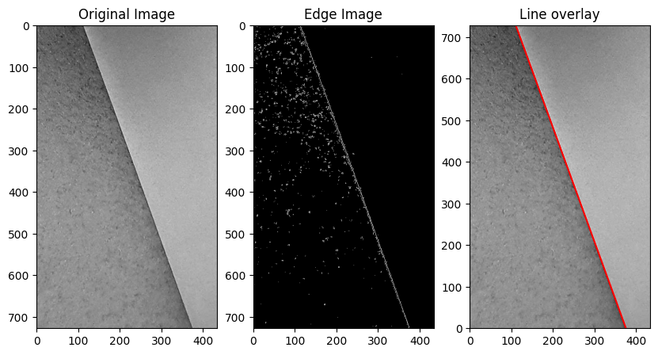

```python
x = np.linspace(0,450,100)
y = slope*x+intercept

img = cv.imread(sample_photo_path,0)

edges = cv.Canny(img,100,100)
plt.subplot(131)
plt.imshow(cv.flip(img, 0),cmap = 'gray')
plt.title('Original Image')

plt.subplot(132)
plt.imshow(cv.flip(edges, 0),cmap = 'gray')
plt.title('Edge Image')

plt.subplot(133)
plt.imshow(img,cmap = 'gray')
plt.plot(x, y, '-r')
plt.ylim((0,728))
plt.xlim((0,434))
plt.title('Line overlay')

plt.show()
```

The red line drawn over the original image on the rightmost photo was drawn by calculating the results slope intercept equation:

$$ y = -2.75x + 1032.53 $$

It intercepts the y-axis at point (0, 1032) (not visible on the plot) and it intercepts the x-axis at

$$ 0 = -2.75x + 1032.53 $$$$ -2.75x = -1032.53 $$$$ x = 375.46 $$

## Line fitting using Hough Transform

We see that Hough transform is capable of detecting a straight line provided an edge image.  
Would it be possible to use it to fit a straight line in a linear regression problem if we replace the edge image with a dataset?

First we need to do a small change to the code as we will be not working with images anymore.

```python
def naive_hough_line_fit(data, num_r, num_theta):
    """
    A basic hough transform implementation
    """

    # calculate step size of thetas and create an array of theta values
    step_theta = 180 / num_theta  # angle step size will be 0.5 degree
    theta_values = np.arange(0, 180, step=step_theta)

    # precalculate cosine and sine values of theta angles
    theta_values_cos = np.cos(np.deg2rad(theta_values))
    theta_values_sin = np.sin(np.deg2rad(theta_values))

    distance_max = np.sqrt(2 * np.square(np.max(data)))
    r_step = (2 * distance_max) / num_r
    r_values = np.arange(-distance_max, distance_max, step=r_step)

    # initialize accumulator matrix
    # accumulator = np.zeros((len(r_values), len(theta_values)))
    r_len = len(r_values)
    theta_len = len(theta_values)
    accumulator = np.zeros((theta_len, r_len))

    hough_plot = []
    for dp in data:
        ys, xs = [], [] # y and x values of hough transform
        for theta_idx in range(len(theta_values)):
            rho = (dp[0] * theta_values_cos[theta_idx]) + (dp[1] * theta_values_sin[theta_idx])
            theta = theta_values[theta_idx]
            rho_idx = np.argmin(np.abs(r_values - rho))

            accumulator[theta_idx][rho_idx] += 1
            ys.append(rho)
            xs.append(theta)

        hough_plot.append([ys,xs])

    return accumulator, hough_plot, theta_values, r_values
```

Let's try it on the used car dataset: https://www.kaggle.com/code/ronikdedhia/car-price/data

```python
car_data = pd.read_csv("resources/dataset/CarPrice_Assignment.csv")
car_data.head()
```

|  | car_ID | symboling | CarName | fueltype | aspiration | doornumber | carbody | drivewheel | enginelocation | wheelbase | ... | enginesize | fuelsystem | boreratio | stroke | compressionratio | horsepower | peakrpm | citympg | highwaympg | price |
| --- | --- | --- | --- | --- | --- | --- | --- | --- | --- | --- | --- | --- | --- | --- | --- | --- | --- | --- | --- | --- | --- |
| 0 | 1 | 3 | alfa-romero giulia | gas | std | two | convertible | rwd | front | 88.6 | ... | 130 | mpfi | 3.47 | 2.68 | 9.0 | 111 | 5000 | 21 | 27 | 13495.0 |
| 1 | 2 | 3 | alfa-romero stelvio | gas | std | two | convertible | rwd | front | 88.6 | ... | 130 | mpfi | 3.47 | 2.68 | 9.0 | 111 | 5000 | 21 | 27 | 16500.0 |
| 2 | 3 | 1 | alfa-romero Quadrifoglio | gas | std | two | hatchback | rwd | front | 94.5 | ... | 152 | mpfi | 2.68 | 3.47 | 9.0 | 154 | 5000 | 19 | 26 | 16500.0 |
| 3 | 4 | 2 | audi 100 ls | gas | std | four | sedan | fwd | front | 99.8 | ... | 109 | mpfi | 3.19 | 3.40 | 10.0 | 102 | 5500 | 24 | 30 | 13950.0 |
| 4 | 5 | 2 | audi 100ls | gas | std | four | sedan | 4wd | front | 99.4 | ... | 136 | mpfi | 3.19 | 3.40 | 8.0 | 115 | 5500 | 18 | 22 | 17450.0 |

5 rows × 26 columns

```python
car_data.info()
```

```
<class 'pandas.core.frame.DataFrame'>
RangeIndex: 205 entries, 0 to 204
Data columns (total 26 columns):
 #   Column            Non-Null Count  Dtype
---  ------            --------------  -----
 0   car_ID            205 non-null    int64
 1   symboling         205 non-null    int64
 2   CarName           205 non-null    object
 3   fueltype          205 non-null    object
 4   aspiration        205 non-null    object
 5   doornumber        205 non-null    object
 6   carbody           205 non-null    object
 7   drivewheel        205 non-null    object
 8   enginelocation    205 non-null    object
 9   wheelbase         205 non-null    float64
```

[output cut: 18 more lines]

```python
df = car_data[['horsepower','price']].copy()
```

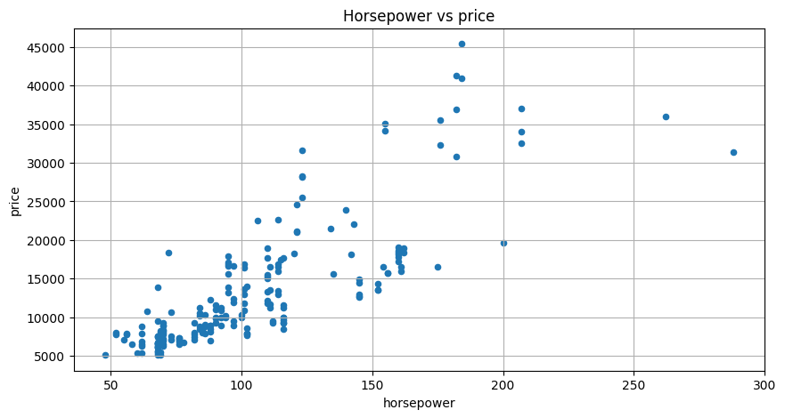

```python
_ = df.plot(kind='scatter',
            x='horsepower',
            y='price',
            title="Horsepower vs price",
            grid=True,
            fontsize=10
           )
```

There seems to be some kind of linear relation by just looking at the horsepower - price scatterplot, so we will focus on these two variables only.

Let's first build a simple linear regression model on the data. (A simple LinearRegression from sklear without fine tunnig will do just fine in this case)

As Hough transform is sensitive to scale it makes sense to scale the price down to the same range as the horsepower. (divison by 120)

```python
from sklearn.linear_model import LinearRegression, Lasso

df['price'] /= 120

x = df['horsepower'].values.reshape(-1, 1)
y = df['price'].values

lr = LinearRegression().fit(x, y)

slope = lr.coef_[0]
intercept = lr.intercept_

print(f"Slope: {slope}")
print(f"Intercept: {intercept}")
```

```
Slope: 1.3605255080803993
Intercept: -31.014679119356316
```

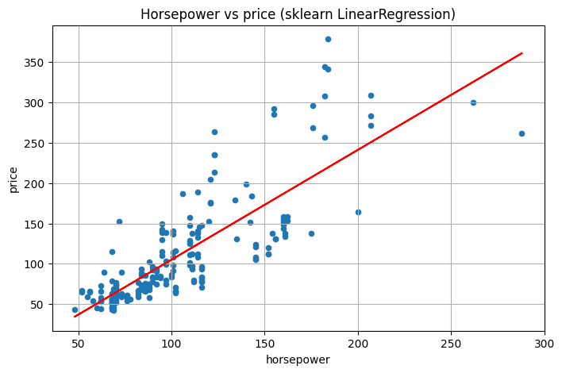

```python
fig, ax = plt.subplots(figsize=(8,5))
_ = df.plot(kind='scatter',
            x='horsepower',
            y='price',
            title="Horsepower vs price (sklearn LinearRegression)",
            grid=True,
            fontsize=10,
            ax=ax
           )

abline_values = [slope * i + intercept for i in df.horsepower]
_ = ax.plot(df.horsepower, abline_values, '-', c='r')
```

Let's try to do the same in a naive way using our hough transform.  
Given there are many datapoints that are scattered all over the place it would be better to have less accumulator cells. This way we increase the probability of more lines falling into the same cell thus giving a better result.

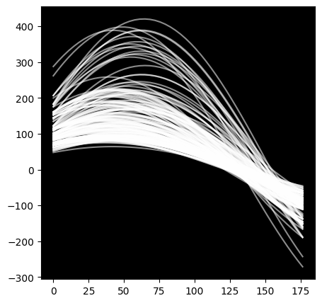

```python
data = df[["horsepower", "price"]].values.tolist()

accumulator, hough_plot, theta_values, r_values = naive_hough_line_fit(data, 50, 50)

figure = plt.figure(figsize=(5, 5))
subplot3 = figure.add_subplot(1, 1, 1)
subplot3.set_facecolor((0, 0, 0))

for p in hough_plot:
    subplot3.plot(p[1], p[0], color="white", alpha=0.55)
plt.show()
```

```python
max_theta_idx, max_rho_idx = np.unravel_index(accumulator.argmax(), accumulator.shape)

print(f'Accumulator cell with most votes: ({max_rho_idx}, {max_theta_idx})')
```

```
Accumulator cell with most votes: (23, 43)
```

```python
max_theta = theta_values[max_theta_idx]
max_r = r_values[max_rho_idx]

print(f'Theta: {max_theta}')
print(f'R: {max_r}')
```

```
Theta: 154.8
R: -42.80353048782672
```

```
2.1251081731572037
-100.52985510518891
```

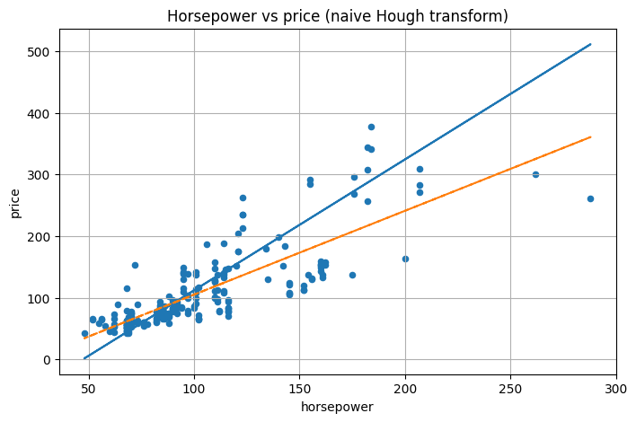

```python
theta_rad = np.deg2rad(max_theta)

slope = -(1/np.tan(theta_rad))
print(slope)

intercept = max_r*(1/np.sin(theta_rad))
print(intercept)

fig, ax = plt.subplots(figsize=(8,5))
df.plot(kind='scatter', x='horsepower', y='price',title="Horsepower vs price (naive Hough transform)", grid=True,fontsize=10, ax=ax)

abline_values = [slope * i + intercept for i in df.horsepower]
ax.plot(df.horsepower, abline_values, '-')

slope_poly, intercept_poly = np.polyfit(df.horsepower, df.price, 1)
abline_values_poly = [slope_poly * i + intercept_poly for i in df.horsepower]
_ = ax.plot(df.horsepower, abline_values_poly, '--')
```

It seems our naive way of line fitting using Hough is not very accurate. The line with the most points will be chosen as the best fit and this is not what we want when trying to fit a line to the data.

Let's try a different approach. What if instead of selecting the accumulator cell with most votes we take a weighted average of all cells with a certain threshold and use the average theta and rho as our parameters.

```python
def average_hough_line_fit(data, num_r, num_theta, threshold):
    """
    Hough line algorithm that returns the average theta and rho parameters.
    """

    # calculate step size of thetas and create an array of theta values
    step_theta = 180 / num_theta  # angle step size will be 0.5 degree
    theta_values = np.arange(0, 180, step=step_theta)

    # precalculate cosine and sine values of theta angles
    theta_values_cos = np.cos(np.deg2rad(theta_values))
    theta_values_sin = np.sin(np.deg2rad(theta_values))

    distance_max = np.sqrt(2 * np.square(np.max(data)))
    r_step = (2 * distance_max) / num_r
    r_values = np.arange(-distance_max, distance_max, step=r_step)

    # initialize accumulator matrix
    r_len = len(r_values)
    theta_len = len(theta_values)
    accumulator = np.zeros((theta_len, r_len))

    hough_plot = []
    for dp in data:
        ys, xs = [], []  # y and x values of hough transform
        for theta_idx in range(len(theta_values)):
            rho = (dp[0] * theta_values_cos[theta_idx]) + (dp[1] * theta_values_sin[theta_idx])
            theta = theta_values[theta_idx]
            rho_idx = np.argmin(np.abs(r_values - rho))

            accumulator[theta_idx][rho_idx] += 1
            ys.append(rho)
            xs.append(theta)

        hough_plot.append([ys, xs])

    average_theta = 0
    average_rho = 0
    total = 0
    for x in range(accumulator.shape[0]):
        for y in range(accumulator.shape[1]):
            if accumulator[x][y] > threshold:
                theta = theta_values[x]
                rho = r_values[y]

                total += accumulator[x][y]
                average_theta += theta * accumulator[x][y]
                average_rho += rho * accumulator[x][y]

    average_theta /= total
    average_rho /= total

    return accumulator, hough_plot, theta_values, r_values, average_theta, average_rho
```

Notice that our function now takes another parameter: threshold  
It determines the threshold for minimum votes in order for the accumulator cell to be considered in the calculation. This helps to increase the accuracy.

```python
(
    accumulator,
    hough_plot,
    theta_values,
    r_values,
    average_theta,
    average_rho
) = average_hough_line_fit(data, 50, 50, 100)
```

Using different values for threshold and the accumulator sizes these parameters seem to work best for our example:

- threshold: 100
- accumulator size: (50x50).

```
Slope: 1.376042046018328
Intercept: -36.47302002056126
slope_poly = 1.3605255080803993
intercept_poly = -31.014679119356327
```

[figure not shown]

```python
theta_rad = np.deg2rad(average_theta)

slope = -(1 / np.tan(theta_rad))
print(f"Slope: {slope}")

intercept = average_rho * (1 / np.sin(theta_rad))
print(f"Intercept: {intercept}")

fig, ax = plt.subplots(figsize=(8, 5))
df.plot(kind='scatter', x='horsepower', y='price', title="horsepower vs price (np.polyfit (blue) vs hough (orange))", grid=True, fontsize=10, ax=ax)

abline_values = [slope * i + intercept for i in df.horsepower]
ax.plot(df.horsepower, abline_values, '-')

slope_poly, intercept_poly = np.polyfit(df.horsepower, df.price, 1)
print(f"{slope_poly = }")
print(f"{intercept_poly = }")
abline_values_poly = [slope_poly * i + intercept_poly for i in df.horsepower]
ax.plot(df.horsepower, abline_values_poly, '--')

plt.show()
```

## Conclusion

The proposed adapted Hough transfrom algorithm is clearly not the most accurate or efficient algoritm one would use for regression. The complexity would increase exponentially when trying to perform linear regression on more than 2 dimensions. E.g. with another independent variable it would need to search for the angle on a 3d sphere meaning each additional ind. variable would add another angle. Furthermore the algorithm's accuracy heavily depends on the hyperparameters (accumulator size and threshold value) which greatly increases time to find the best solution.